# Statistical Testing

Chantal Koechli

2/26/2019

## Central Tendancy

To illustrate these calculations of central tendancy, we’ll use the **Iris** dataset that is built into R.

Exploring the data a bit

```r
head(iris) #shows the first six lines of data
```

```
##   Sepal.Length Sepal.Width Petal.Length Petal.Width Species
## 1          5.1         3.5          1.4         0.2  setosa
## 2          4.9         3.0          1.4         0.2  setosa
## 3          4.7         3.2          1.3         0.2  setosa
## 4          4.6         3.1          1.5         0.2  setosa
## 5          5.0         3.6          1.4         0.2  setosa
## 6          5.4         3.9          1.7         0.4  setosa
```

```r
unique(iris$Species) #shows how many unique entries are in the Species column
```

```
## [1] setosa     versicolor virginica
## Levels: setosa versicolor virginica
```

### Mean

We can find the mean sepal length for the entire dataset (across all species)

```r
mean(iris$Sepal.Length)
```

```
## [1] 5.843333
```

We can also find the mean sepal length for each specific species, by grouping and summarising with dplyr :

```r
library(dplyr) # loading dplyr
iris_summary = iris %>%  #the %>% modifier allows us to chain commands together
                group_by(Species) %>% #grouping data by the species value
                summarise(mean_length = mean(Sepal.Length)) #calculating mean sepal length
iris_summary #looking at our data
```

```
## # A tibble: 3 x 2
##   Species    mean_length
##   <fct>            <dbl>
## 1 setosa            5.01
## 2 versicolor        5.94
## 3 virginica         6.59
```

We can graph this data, too :

```r
library(ggplot2) #loading ggplot2
iris_summary = iris %>%  #the %>% modifier allows us to chain commands together
                group_by(Species) %>% #grouping data by the species value
                summarise(mean_length = mean(Sepal.Length),#calculating mean sepal length
                          sd_length = sd(Sepal.Length)) #calculating sd of sepal length
iris_summary #looking at our data
```

```
## # A tibble: 3 x 3
##   Species    mean_length sd_length
##   <fct>            <dbl>     <dbl>
## 1 setosa            5.01     0.352
## 2 versicolor        5.94     0.516
## 3 virginica         6.59     0.636
```

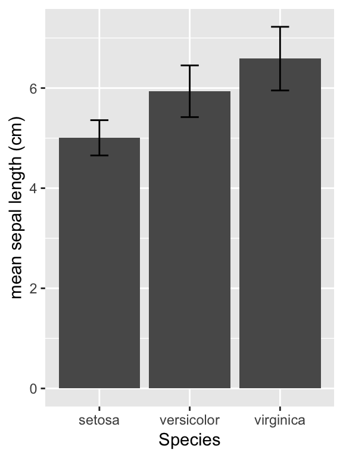

```r
ggplot(iris_summary, #calling out dataset to plot
       aes(x = Species, y = mean_length)) + #specifying x and y values
        geom_bar(stat = "identity") +  #specifying bar plot with discrete x and continous y
        ylab("mean sepal length (cm)") + #changing y label text
        geom_errorbar(aes(x = Species,  #adding error bars
                          ymax = mean_length + sd_length,
                          ymin = mean_length - sd_length,
                          width = 0.2
                          ))
```

### Median

The same can be done with median : we can find the median sepal length for the entire dataset (across all species)

```r
median(iris$Sepal.Length)
```

```
## [1] 5.8
```

We can also find the median sepal length for each specific species, by grouping and summarising with dplyr :

```r
iris_summary = iris %>%  #the %>% modifier allows us to chain commands together
                group_by(Species) %>% #grouping data by the species value
                summarise(median_length = median(Sepal.Length)) #calculating median sepal length
iris_summary #looking at our data
```

```
## # A tibble: 3 x 2
##   Species    median_length
##   <fct>              <dbl>
## 1 setosa               5
## 2 versicolor           5.9
## 3 virginica            6.5
```

### Mode

There is no built in mode function in R!

We can write a function, though :

```r
Mode <- function(x) {
  ux <- unique(x)
  ux[which.max(tabulate(match(x, ux)))]
}
```

Let’s try it out

```r
Mode(iris$Petal.Length)
```

```
## [1] 1.4
```

```r
iris_summary = iris %>%  #the %>% modifier allows us to chain commands together
                group_by(Species) %>% #grouping data by the species value
                summarise(mode_length = Mode(Petal.Length)) #calculating media sepal length
iris_summary #looking at our data
```

```
## # A tibble: 3 x 2
##   Species    mode_length
##   <fct>            <dbl>
## 1 setosa             1.4
## 2 versicolor         4.5
## 3 virginica          5.1
```

## Dispersion

Measures of dispersion are easily calculated :

### Standard Deviation

```r
iris_summary = iris %>%  #the %>% modifier allows us to chain commands together
                group_by(Species) %>% #grouping data by the species value
                summarise(sd_length = sd(Sepal.Length)) #calculating sd of sepal length

iris_summary
```

```
## # A tibble: 3 x 2
##   Species    sd_length
##   <fct>          <dbl>
## 1 setosa         0.352
## 2 versicolor     0.516
## 3 virginica      0.636
```

### Standard Error of Measurement

```r
iris_summary = iris %>%  #the %>% modifier allows us to chain commands together
                group_by(Species) %>% #grouping data by the species value
                summarise(sem_length = sd(Sepal.Length)/sqrt(length(Sepal.Length))) #calculating sem of sepal length

iris_summary
```

```
## # A tibble: 3 x 2
##   Species    sem_length
##   <fct>           <dbl>
## 1 setosa         0.0498
## 2 versicolor     0.0730
## 3 virginica      0.0899
```

### Confidence Intervals

These can be calculated, with help of qt function - quantile function of the Student t distribution :

```r
se = sd/length(variable)

lower.ci = mean - qt(1 - (0.05 / 2), n - 1) * se

upper.ci = mean + qt(1 - (0.05 / 2), n - 1) * se
```

## Chi Square Goodness of Fit

Is probability of car colors equal across black, white, and silver cars?

```r
car_colors = c(81, 50, 27)
results = chisq.test(car_colors, p = c(1/3, 1/3, 1/3))
results
```

```
##
##  Chi-squared test for given probabilities
##
## data:  car_colors
## X-squared = 27.886, df = 2, p-value = 8.803e-07
```

## Chi Square Test of Independence

```r
# Import the data
file_path <- "http://www.sthda.com/sthda/RDoc/data/housetasks.txt"
housetasks <- read.delim(file_path, row.names = 1)
head(housetasks)
```

```
##            Wife Alternating Husband Jointly
## Laundry     156          14       2       4
## Main_meal   124          20       5       4
## Dinner       77          11       7      13
## Breakfeast   82          36      15       7
## Tidying      53          11       1      57
## Dishes       32          24       4      53
```

Visualizing, two ways :

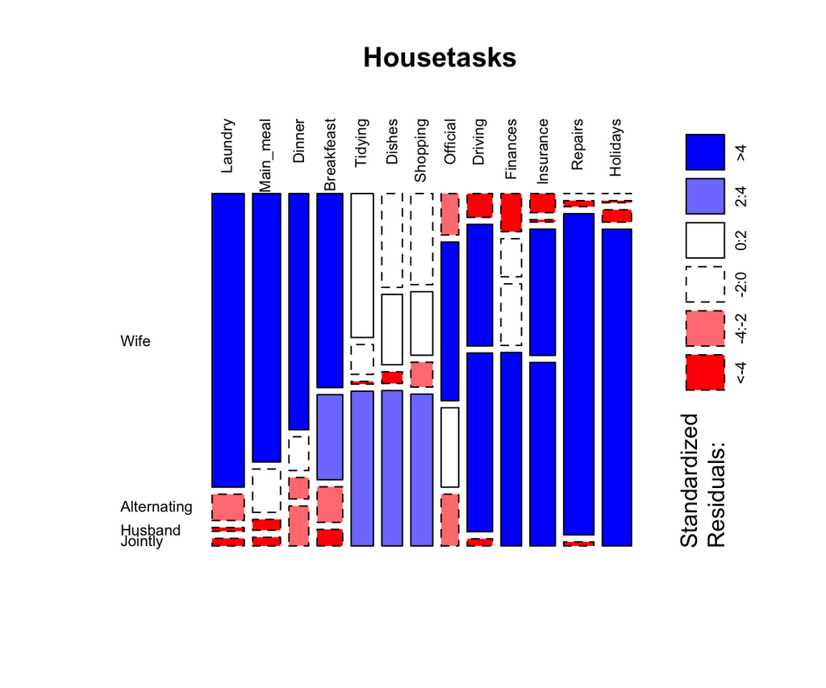

```r
# 1. convert the data as a table
dt <- as.table(as.matrix(housetasks))
# 2. Graph
mosaicplot(dt, shade = TRUE,
           main = "Housetasks", las = 4)
```

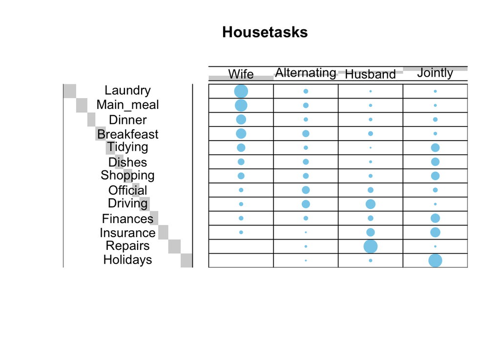

```r
library("gplots")
# 1. convert the data as a table
dt <- as.table(as.matrix(housetasks))
# 2. Graph
balloonplot(t(dt), main ="Housetasks", xlab ="", ylab="",
            label = FALSE, show.margins = FALSE)
```

To create a contingency table, use the `xtabs` command (in base R).

Additional visualizations of contingency tables, with corresponding code, can be found here : http://statmath.wu.ac.at/projects/vcd/

Computing chi-squared

```r
chisq = chisq.test(housetasks)
chisq
```

```
##
##  Pearson's Chi-squared test
##
## data:  housetasks
## X-squared = 1944.5, df = 36, p-value < 2.2e-16
```

## Independent t-test

### Assumption Testing

Creating a dataset to use :

```r
# Data in two numeric vectors
women_weight <- c(38.9, 61.2, 73.3, 21.8, 63.4, 64.6, 48.4, 48.8, 48.5)
men_weight <- c(67.8, 60, 63.4, 76, 89.4, 73.3, 67.3, 61.3, 62.4)
# Create a data frame
my_data <- data.frame(
                group = rep(c("Woman", "Man"), each = 9),
                weight = c(women_weight,  men_weight)
                )
```

#### Normality

```r
women = filter(my_data, group == "Woman")
men = filter(my_data, group == "Man")
```

```r
shapiro.test(women$weight)
```

```
##
##  Shapiro-Wilk normality test
##
## data:  women$weight
## W = 0.94266, p-value = 0.6101
```

```r
shapiro.test(men$weight)
```

```
##
##  Shapiro-Wilk normality test
##
## data:  men$weight
## W = 0.86425, p-value = 0.1066
```

#### Homoscedasticity

```r
results = var.test(weight ~ group, data = my_data)
results
```

```
##
##  F test to compare two variances
##
## data:  weight by group
## F = 0.36134, num df = 8, denom df = 8, p-value = 0.1714
## alternative hypothesis: true ratio of variances is not equal to 1
## 95 percent confidence interval:
##  0.08150656 1.60191315
## sample estimates:
## ratio of variances
##          0.3613398
```

```r
# Data in two numeric vectors
women_weight <- c(38.9, 61.2, 73.3, 21.8, 63.4, 64.6, 48.4, 48.8, 48.5)
men_weight <- c(67.8, 60, 63.4, 76, 89.4, 73.3, 67.3, 61.3, 62.4)
# Create a data frame
my_data <- data.frame(
                group = rep(c("Woman", "Man"), each = 9),
                weight = c(women_weight,  men_weight)
                )
```

### Visualizing and Testing

Visualize the data

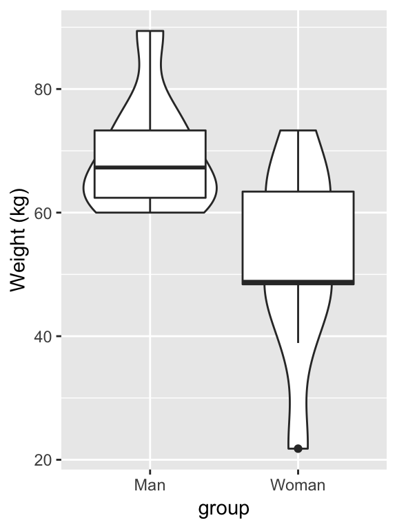

```r
ggplot(my_data, aes(x=group, y = weight)) + geom_violin() +geom_boxplot()+ ylab("Weight (kg)")
```

Running the t-test :

```r
t.test(women_weight, men_weight, var.equal = TRUE)
```

```
##
##  Two Sample t-test
##
## data:  women_weight and men_weight
## t = -2.7842, df = 16, p-value = 0.01327
## alternative hypothesis: true difference in means is not equal to 0
## 95 percent confidence interval:
##  -29.748019  -4.029759
## sample estimates:
## mean of x mean of y
##  52.10000  68.98889
```

```r
wilcox.test(women_weight, men_weight,paired=FALSE)
```

```
##
##  Wilcoxon rank sum test with continuity correction
##
## data:  women_weight and men_weight
## W = 15, p-value = 0.02712
## alternative hypothesis: true location shift is not equal to 0
```

## Dependent t-test / Paired t-test

We’ll use the built in `sleep` dataset, showing effect of two drugs (increase in hours of sleep compared to control) on 10 patients:

```r
head(sleep)
```

```
##   extra group ID
## 1   0.7     1  1
## 2  -1.6     1  2
## 3  -0.2     1  3
## 4  -1.2     1  4
## 5  -0.1     1  5
## 6   3.4     1  6
```

```r
unique(sleep$group)
```

```
## [1] 1 2
## Levels: 1 2
```

```r
unique(sleep$ID)
```

```
##  [1] 1  2  3  4  5  6  7  8  9  10
## Levels: 1 2 3 4 5 6 7 8 9 10
```

Let’s visualize the data:

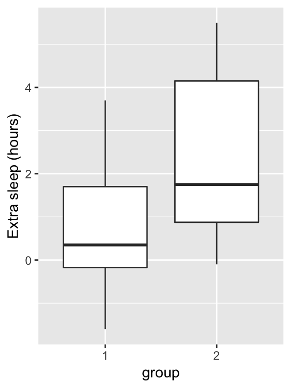

```r
ggplot(sleep, aes(x=group, y = extra)) + geom_boxplot() + ylab("Extra sleep (hours)")
```

Running the paired t-test

```r
t.test(extra ~ group, sleep, paired=TRUE)
```

```
##
##  Paired t-test
##
## data:  extra by group
## t = -4.0621, df = 9, p-value = 0.002833
## alternative hypothesis: true difference in means is not equal to 0
## 95 percent confidence interval:
##  -2.4598858 -0.7001142
## sample estimates:
## mean of the differences
##                   -1.58
```

You can also do a one sample t-test:

```r
t.test(sleep$extra, mu=0)
```

```
##
##  One Sample t-test
##
## data:  sleep$extra
## t = 3.413, df = 19, p-value = 0.002918
## alternative hypothesis: true mean is not equal to 0
## 95 percent confidence interval:
##  0.5955845 2.4844155
## sample estimates:
## mean of x
##      1.54
```

## Dependent Wilcoxon Signed Rank Test

```r
wilcox.test(women_weight, men_weight,paired=TRUE)
```

```
##
##  Wilcoxon signed rank test
##
## data:  women_weight and men_weight
## V = 4, p-value = 0.02734
## alternative hypothesis: true location shift is not equal to 0
```

## Correlation

Correlation between petal width and petal length in iris dataset using the cor.test() function that is in base R.

- Note that sample estimate output is effect size r.
- The method can be adjusted to “spearman” or “kendall”.
- Looking at ?cor.test() provides more explanation of methodology and also additional arguments that can be added to the function.

```r
iris_num = iris %>% select(-Species) #removing the species column from the iris dataset, as the corr.test function only takes numeric data
cor.test(~iris_num$Petal.Width + iris_num$Petal.Length, #specifying formula for correlation
          method = "pearson") # can change to spearman or kendall
```

```
##
##  Pearson's product-moment correlation
##
## data:  iris_num$Petal.Width and iris_num$Petal.Length
## t = 43.387, df = 148, p-value < 2.2e-16
## alternative hypothesis: true correlation is not equal to 0
## 95 percent confidence interval:
##  0.9490525 0.9729853
## sample estimates:
##       cor
## 0.9628654
```

There are also packages that facilitate visualization and testing of multiple correlations:

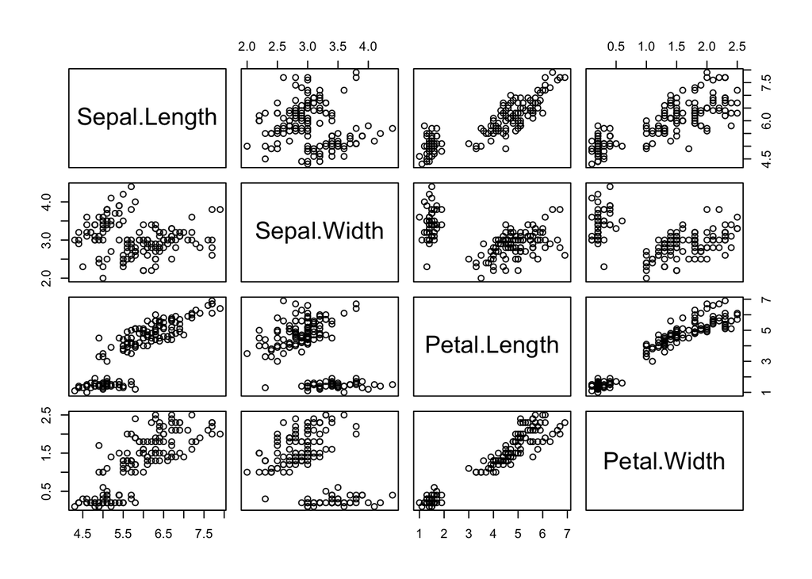

```r
library(psych) #loading psych library
pairs(data=iris,
    ~ Sepal.Length + Sepal.Width + Petal.Length + Petal.Width) # plots pairwise comparisions of data
```

```r
iris_num = iris %>% select(-Species) #removing the species column from the iris dataset, as the corr.test function only takes numeric data

corr.test(iris_num,
          use    = "pairwise",
          method = "pearson", # can change to spearman
          adjust = "BH") #adjusting p-values for multiple comparisons via Benjamini Hochberg method. Can also input "holm", "hochberg", "hommel", "bonferroni", "BY","fdr", "none". See ?p.adjust() for more details about different choices
```

```
## Call:corr.test(x = iris_num, use = "pairwise", method = "pearson",
##     adjust = "BH")
## Correlation matrix
##              Sepal.Length Sepal.Width Petal.Length Petal.Width
## Sepal.Length         1.00       -0.12         0.87        0.82
## Sepal.Width         -0.12        1.00        -0.43       -0.37
## Petal.Length         0.87       -0.43         1.00        0.96
## Petal.Width          0.82       -0.37         0.96        1.00
## Sample Size
## [1] 150
## Probability values (Entries above the diagonal are adjusted for multiple tests.)
##              Sepal.Length Sepal.Width Petal.Length Petal.Width
## Sepal.Length         0.00        0.15            0           0
## Sepal.Width          0.15        0.00            0           0
## Petal.Length         0.00        0.00            0           0
## Petal.Width          0.00        0.00            0           0
##
##  To see confidence intervals of the correlations, print with the short=FALSE option
```

## Regression

Let’s take a look at the dataset `cars`: speed and corresponding stopping distance of cars.

```r
head(cars)
```

```
##   speed dist
## 1     4    2
## 2     4   10
## 3     7    4
## 4     7   22
## 5     8   16
## 6     9   10
```

Let’s graph:

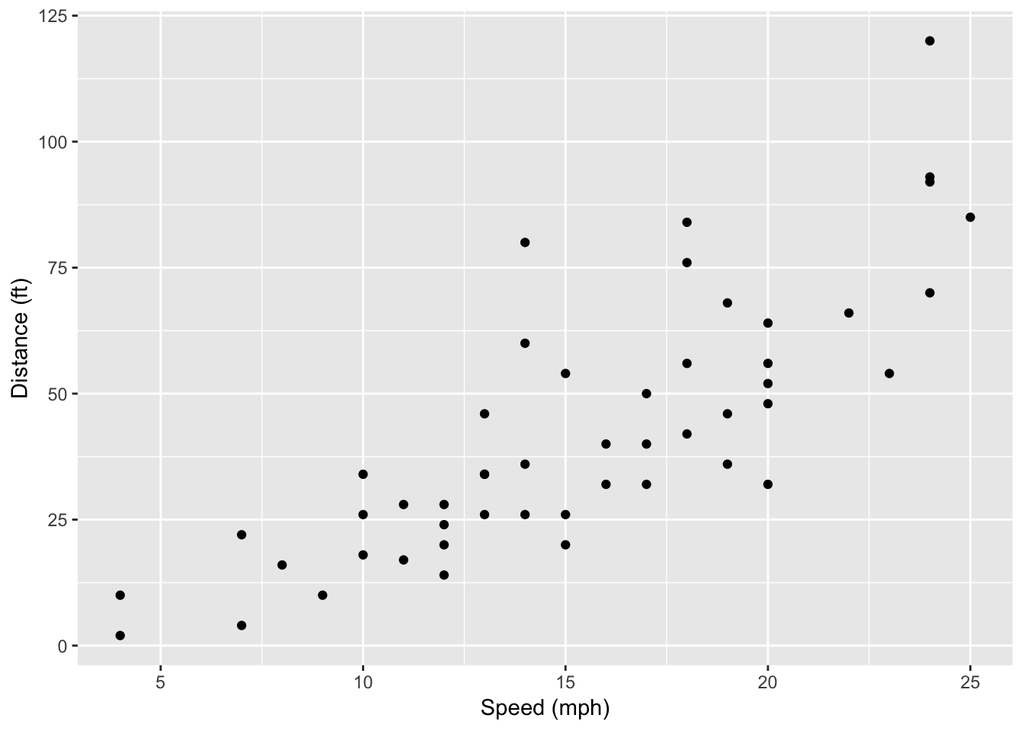

```r
ggplot(cars, aes(x = speed, y = dist)) + #establishing x and y
      geom_point() + #specifying scatterplot
      xlab("Speed (mph)") + #changing x-axis label
      ylab("Distance (ft)") #changing y label
```

Let’s fit a linear model. Note that ?lm() provides more arguments for the function, including addition of a vector of weights.

```r
car_model = lm(dist ~ speed, #specifying formula for model
           data = cars) #specifying dataset to use

summary(car_model) #printout of regression results
```

```
##
## Call:
## lm(formula = dist ~ speed, data = cars)
##
## Residuals:
##     Min      1Q  Median      3Q     Max
## -29.069  -9.525  -2.272   9.215  43.201
##
## Coefficients:
##             Estimate Std. Error t value Pr(>|t|)
## (Intercept) -17.5791     6.7584  -2.601   0.0123 *
## speed         3.9324     0.4155   9.464 1.49e-12 ***
## ---
## Signif. codes:  0 '***' 0.001 '**' 0.01 '*' 0.05 '.' 0.1 ' ' 1
##
## Residual standard error: 15.38 on 48 degrees of freedom
## Multiple R-squared:  0.6511, Adjusted R-squared:  0.6438
## F-statistic: 89.57 on 1 and 48 DF,  p-value: 1.49e-12
```

Can we plot the linear model?

Yes!

- Note that the default is for standard error of the linear model to plot as well.
- Other options under method include “auto”, “glm”, “gam”, “loess”, or you can specify a specific function.
- ?geom_smooth() provides more information about function options.

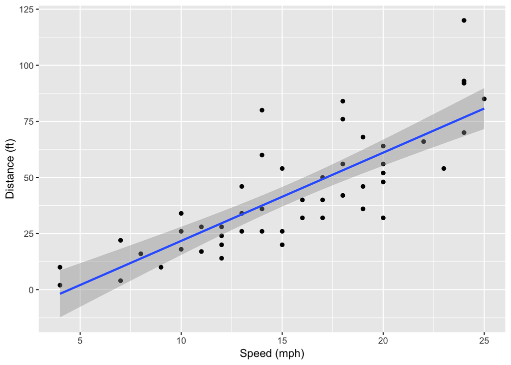

```r
ggplot(cars, aes(x = speed, y = dist)) + #establishing x and y
      geom_point() + #specifying scatterplot
      xlab("Speed (mph)")+ #changing x-axis label
      ylab("Distance (ft)")+ #changing y label
      geom_smooth(method = "lm") #adding linear model line
```

#### Checking Assumptions

```r
library(broom)
model.diag.metrics <- augment(car_model)
head(model.diag.metrics)
```

```
## # A tibble: 6 x 9
##    dist speed .fitted .se.fit .resid   .hat .sigma  .cooksd .std.resid
##   <dbl> <dbl>   <dbl>   <dbl>  <dbl>  <dbl>  <dbl>    <dbl>      <dbl>
## 1     2     4   -1.85    5.21   3.85 0.115    15.5 0.00459       0.266
## 2    10     4   -1.85    5.21  11.8  0.115    15.4 0.0435        0.819
## 3     4     7    9.95    4.11  -5.95 0.0715   15.5 0.00620      -0.401
## 4    22     7    9.95    4.11  12.1  0.0715   15.4 0.0255        0.813
## 5    16     8   13.9     3.77   2.12 0.0600   15.5 0.000645      0.142
## 6    10     9   17.8     3.44  -7.81 0.0499   15.5 0.00713      -0.521
```

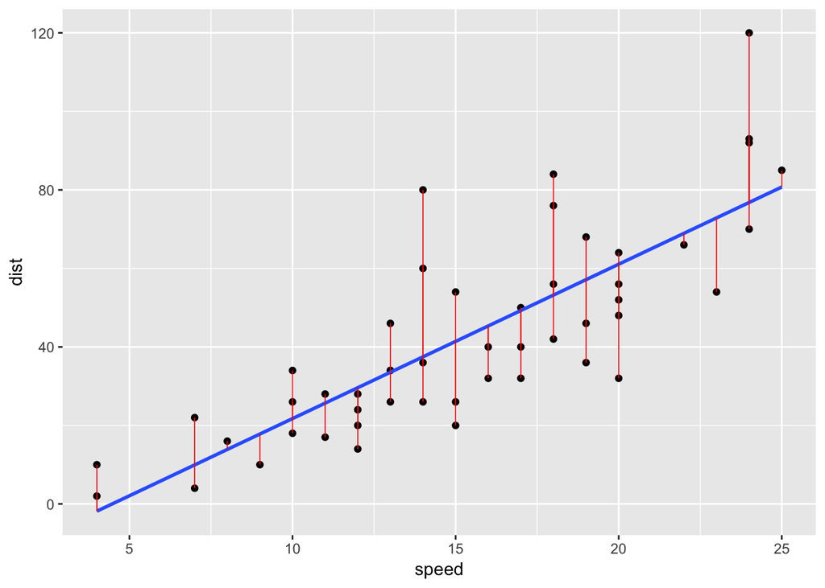

```r
ggplot(model.diag.metrics, aes(speed, dist)) +
  geom_point() +
  stat_smooth(method = lm, se = FALSE) +
  geom_segment(aes(xend = speed, yend = .fitted), color = "red", size = 0.3)
```

Looking at linearity of data with residuals vs fitted plot

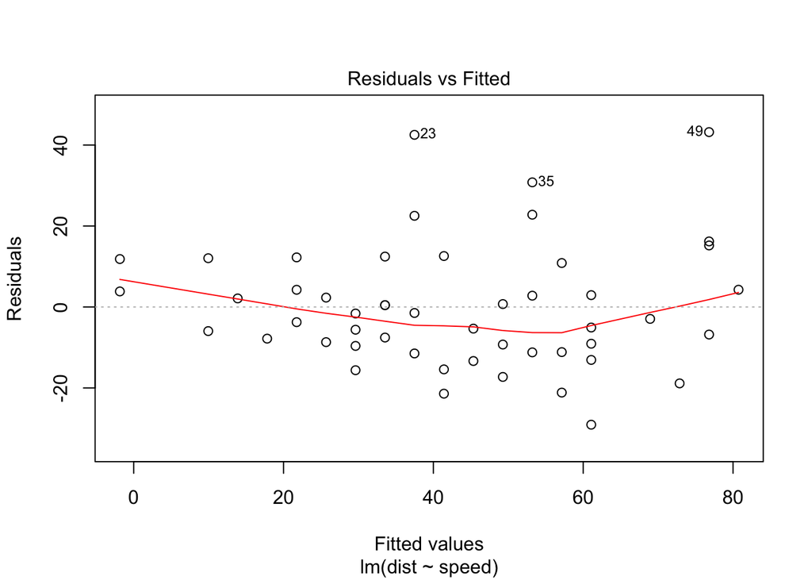

```r
plot(car_model,1)
```

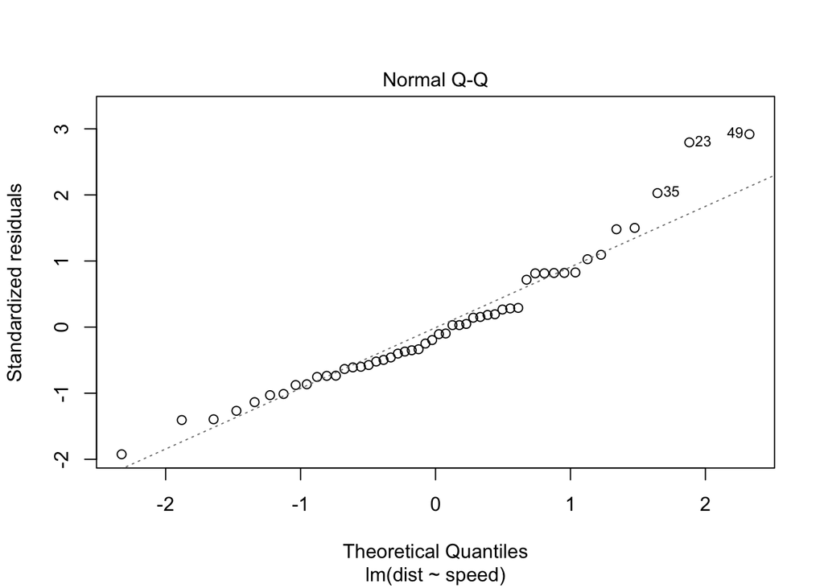

```r
plot(car_model, 2)
```

Looking at homoscedasticity with spread-location (scale-location) plot

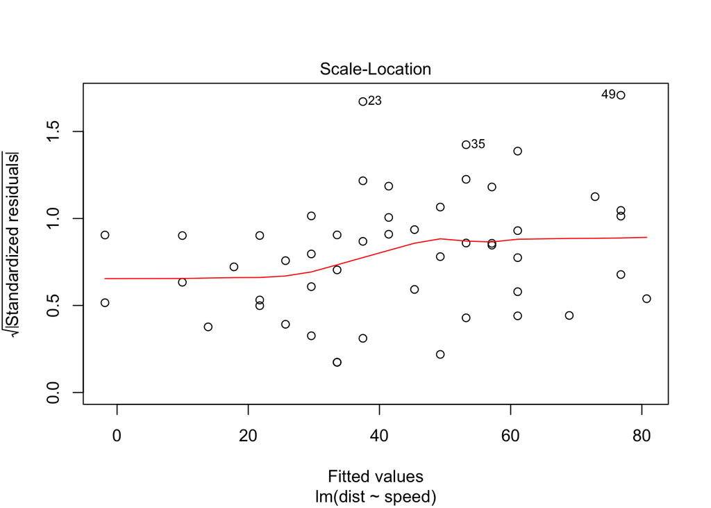

```r
plot(car_model, 3)
```

Additional plots

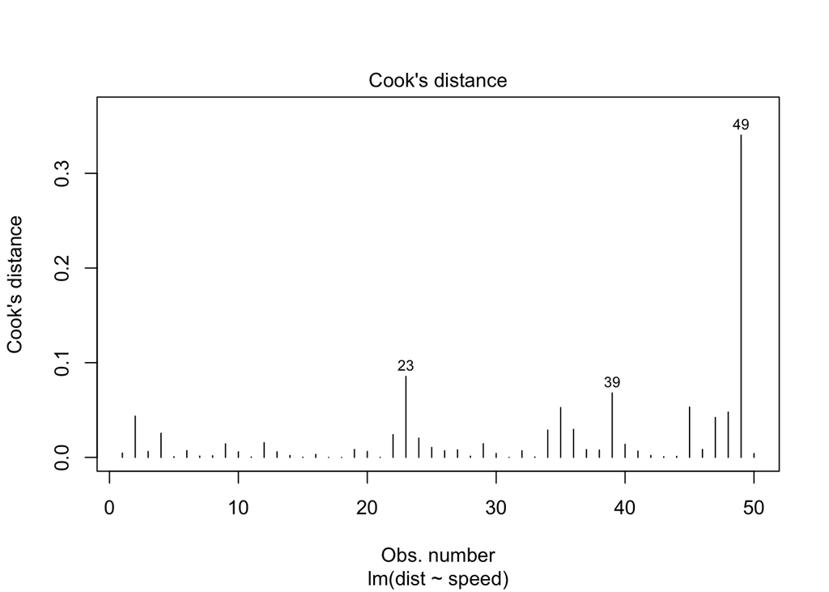

```r
# Cook's distance (an observation has high influence if Cook’s distance exceeds 4/(n - p - 1) - P. Bruce and Bruce 2017)
plot(car_model, 4)
```

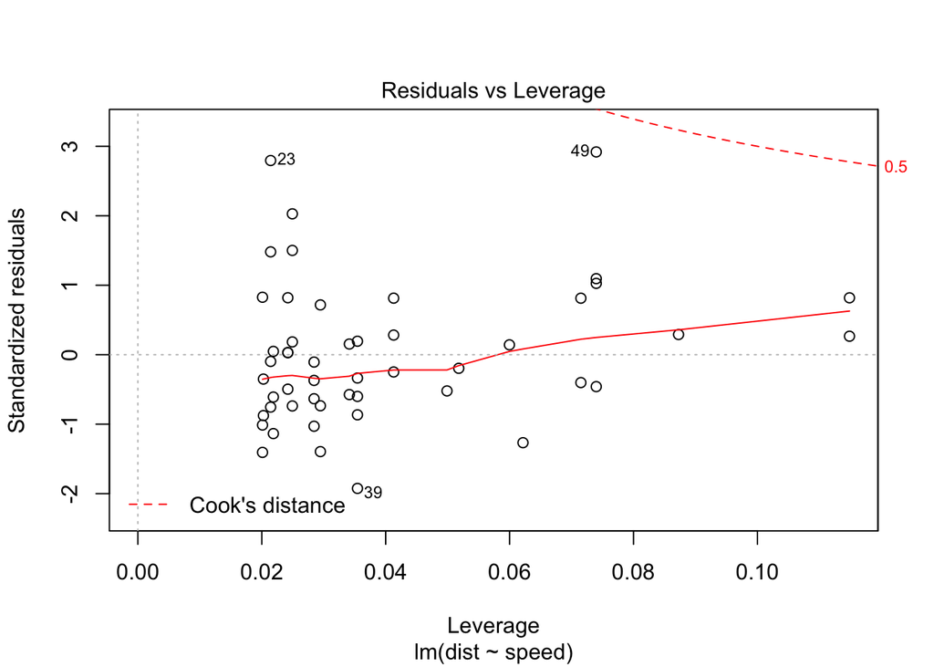

```r
# Residuals vs Leverage (outlying values are generally located at the upper right corner or at the lower right corner)
plot(car_model, 5)
```

## One-Way ANOVA between sum of squares

Let’s take a look at the dataset Plant Growth, testing impact of three treatments on plant yield (dry plant weight)

```r
head(PlantGrowth)
```

```
##   weight group
## 1   4.17  ctrl
## 2   5.58  ctrl
## 3   5.18  ctrl
## 4   6.11  ctrl
## 5   4.50  ctrl
## 6   4.61  ctrl
```

Unique treatments

```r
unique(PlantGrowth$group)
```

```
## [1] ctrl trt1 trt2
## Levels: ctrl trt1 trt2
```

Let’s graph:

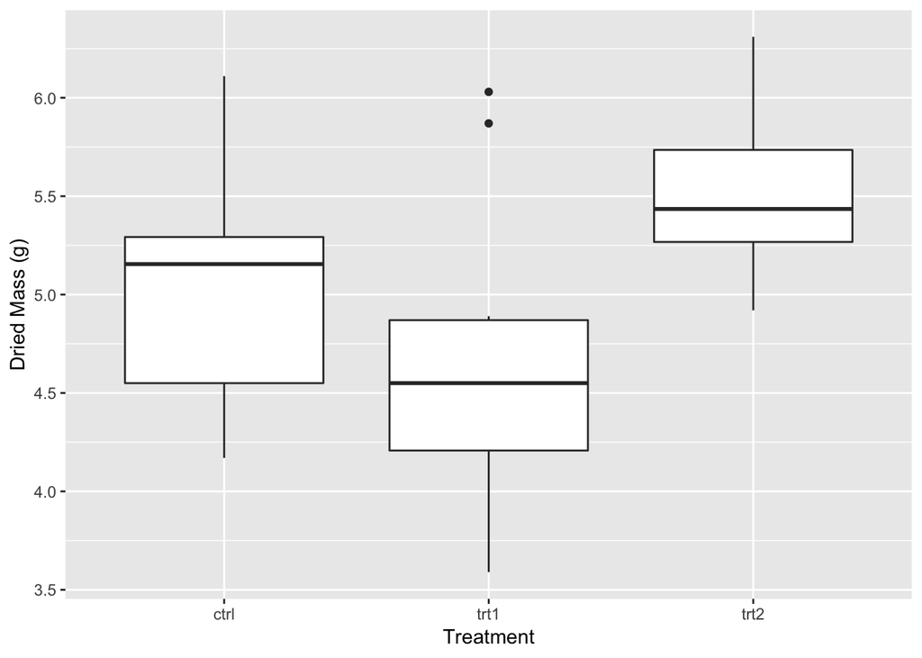

```r
ggplot(PlantGrowth, aes(x = group, y = weight)) +
        geom_boxplot() +
        ylab("Dried Mass (g)") +
        xlab("Treatment")
```

Now running the ANOVA

```r
aov_plant = aov(lm(weight ~ group, data = PlantGrowth))
summary(aov_plant)
```

```
##             Df Sum Sq Mean Sq F value Pr(>F)
## group        2  3.766  1.8832   4.846 0.0159 *
## Residuals   27 10.492  0.3886
## ---
## Signif. codes:  0 '***' 0.001 '**' 0.01 '*' 0.05 '.' 0.1 ' ' 1
```

Post-hoc testing

```r
tukey = TukeyHSD(aov_plant)
tukey
```

```
##   Tukey multiple comparisons of means
##     95% family-wise confidence level
##
## Fit: aov(formula = lm(weight ~ group, data = PlantGrowth))
##
## $group
##             diff        lwr       upr     p adj
## trt1-ctrl -0.371 -1.0622161 0.3202161 0.3908711
## trt2-ctrl  0.494 -0.1972161 1.1852161 0.1979960
## trt2-trt1  0.865  0.1737839 1.5562161 0.0120064
```

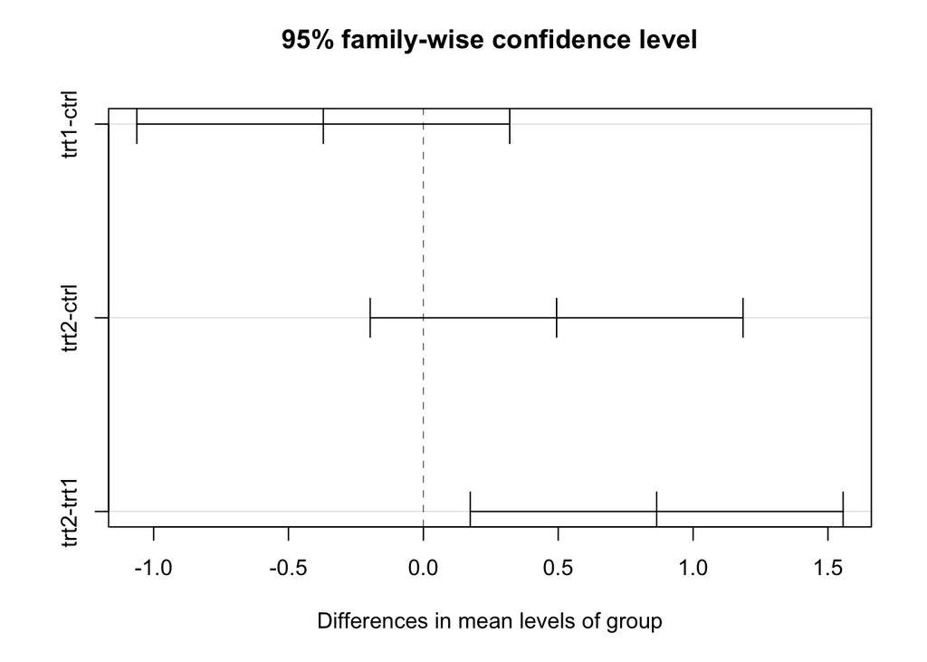

```r
plot(tukey)
```

#### Checking Assumptions

Homogeneity of Variance

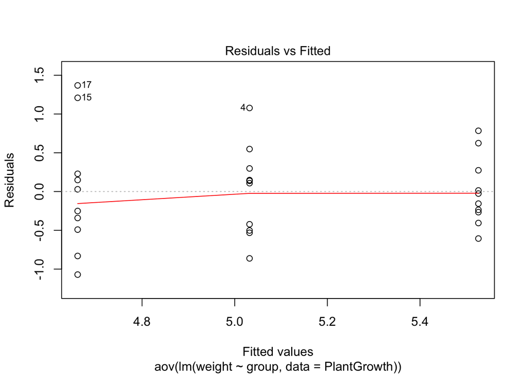

```r
plot(aov_plant, 1)
```

```r
library(car)
leveneTest(weight ~ group, data = PlantGrowth)
```

```
## Levene's Test for Homogeneity of Variance (center = median)
##       Df F value Pr(>F)
## group  2  1.1192 0.3412
##       27
```

Normality

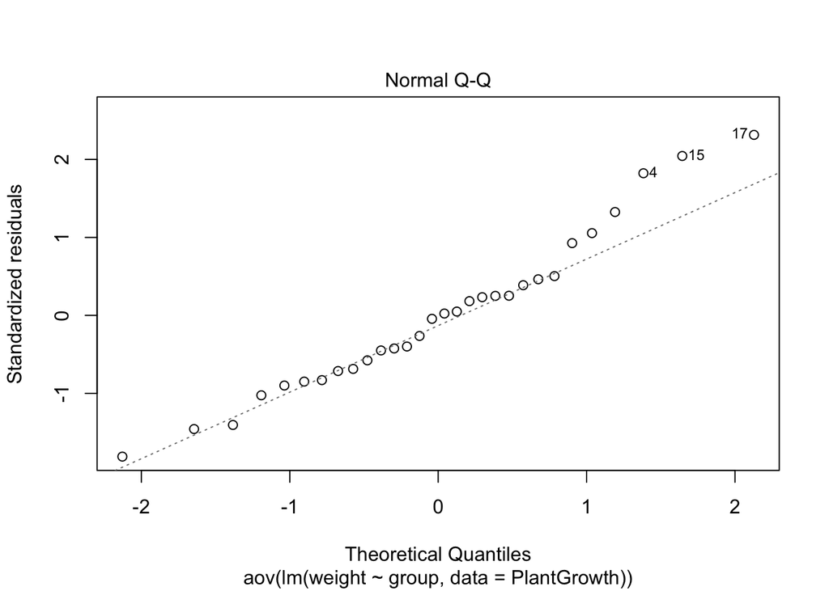

```r
plot(aov_plant, 2)
```

```r
# Extract the residuals
aov_residuals <- residuals(object = aov_plant )
# Run Shapiro-Wilk test
shapiro.test(x = aov_residuals )
```

```
##
##  Shapiro-Wilk normality test
##
## data:  aov_residuals
## W = 0.96607, p-value = 0.4379
```

#### Non-Parametric Option : Kruskal Wallis

```r
kruskal.test(weight ~ group, data = PlantGrowth)
```

```
##
##  Kruskal-Wallis rank sum test
##
## data:  weight by group
## Kruskal-Wallis chi-squared = 7.9882, df = 2, p-value = 0.01842
```

## Factorial ANOVA

Let’s take a look at the dataset ToothGrowth, testing impact of Vitamin C on tooth growth in guinea pigs

```r
head(ToothGrowth)
```

```
##    len supp dose
## 1  4.2   VC  0.5
## 2 11.5   VC  0.5
## 3  7.3   VC  0.5
## 4  5.8   VC  0.5
## 5  6.4   VC  0.5
## 6 10.0   VC  0.5
```

Let’s look at the structure of the data :

```r
str(ToothGrowth)
```

```
## 'data.frame':    60 obs. of  3 variables:
##  $ len : num  4.2 11.5 7.3 5.8 6.4 10 11.2 11.2 5.2 7 ...
##  $ supp: Factor w/ 2 levels "OJ","VC": 2 2 2 2 2 2 2 2 2 2 ...
##  $ dose: num  0.5 0.5 0.5 0.5 0.5 0.5 0.5 0.5 0.5 0.5 ...
```

```r
ToothGrowth$dose = as.factor(ToothGrowth$dose)
```

```r
str(ToothGrowth)
```

```
## 'data.frame':    60 obs. of  3 variables:
##  $ len : num  4.2 11.5 7.3 5.8 6.4 10 11.2 11.2 5.2 7 ...
##  $ supp: Factor w/ 2 levels "OJ","VC": 2 2 2 2 2 2 2 2 2 2 ...
##  $ dose: Factor w/ 3 levels "0.5","1","2": 1 1 1 1 1 1 1 1 1 1 ...
```

Let’s graph:

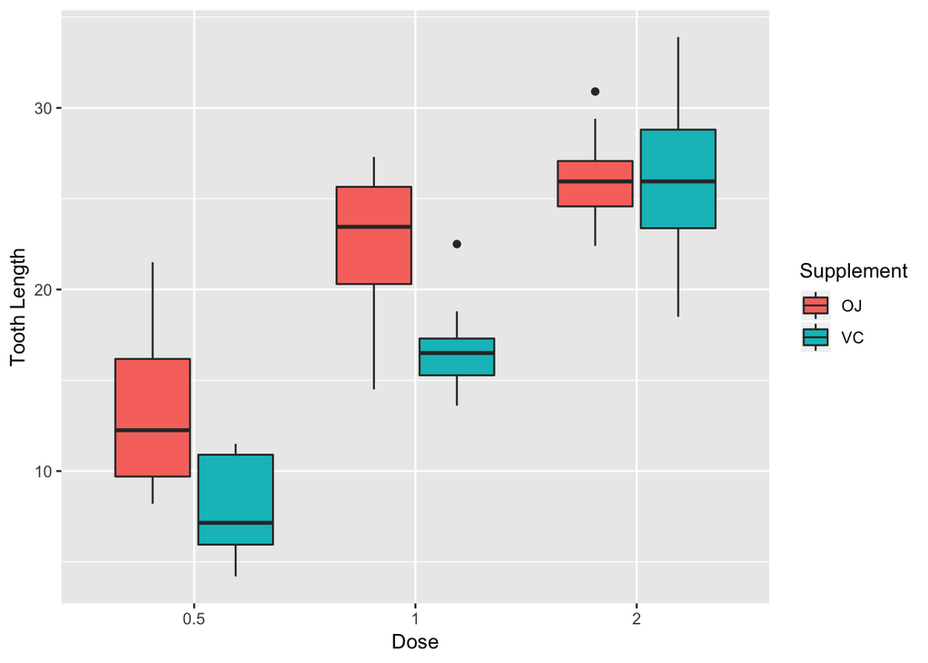

```r
ggplot(ToothGrowth, aes(x = dose, y = len, fill = supp)) +
        geom_boxplot() +
        ylab("Tooth Length") +
        xlab("Dose") +
        scale_fill_discrete(name="Supplement")
```

```r
model = aov(len ~ dose + supp + dose:supp,
           data = ToothGrowth)
summary(model)
```

```
##             Df Sum Sq Mean Sq F value   Pr(>F)
## dose         2 2426.4  1213.2  92.000  < 2e-16 ***
## supp         1  205.4   205.4  15.572 0.000231 ***
## dose:supp    2  108.3    54.2   4.107 0.021860 *
## Residuals   54  712.1    13.2
## ---
## Signif. codes:  0 '***' 0.001 '**' 0.01 '*' 0.05 '.' 0.1 ' ' 1
```

Post-hoc testing

```r
TukeyHSD(model, ordered = TRUE)
```

```
##   Tukey multiple comparisons of means
##     95% family-wise confidence level
##     factor levels have been ordered
##
## Fit: aov(formula = len ~ dose + supp + dose:supp, data = ToothGrowth)
##
## $dose
##         diff       lwr       upr   p adj
## 1-0.5  9.130  6.362488 11.897512 0.0e+00
## 2-0.5 15.495 12.727488 18.262512 0.0e+00
## 2-1    6.365  3.597488  9.132512 2.7e-06
##
## $supp
##       diff      lwr      upr     p adj
## OJ-VC  3.7 1.820172 5.579828 0.0002312
##
## $`dose:supp`
##                diff        lwr       upr     p adj
## 0.5:OJ-0.5:VC  5.25  0.4518762 10.048124 0.0242521
## 1:VC-0.5:VC    8.79  3.9918762 13.588124 0.0000210
## 1:OJ-0.5:VC   14.72  9.9218762 19.518124 0.0000000
## 2:OJ-0.5:VC   18.08 13.2818762 22.878124 0.0000000
## 2:VC-0.5:VC   18.16 13.3618762 22.958124 0.0000000
## 1:VC-0.5:OJ    3.54 -1.2581238  8.338124 0.2640208
## 1:OJ-0.5:OJ    9.47  4.6718762 14.268124 0.0000046
## 2:OJ-0.5:OJ   12.83  8.0318762 17.628124 0.0000000
## 2:VC-0.5:OJ   12.91  8.1118762 17.708124 0.0000000
## 1:OJ-1:VC      5.93  1.1318762 10.728124 0.0073930
## 2:OJ-1:VC      9.29  4.4918762 14.088124 0.0000069
## 2:VC-1:VC      9.37  4.5718762 14.168124 0.0000058
## 2:OJ-1:OJ      3.36 -1.4381238  8.158124 0.3187361
## 2:VC-1:OJ      3.44 -1.3581238  8.238124 0.2936430
## 2:VC-2:OJ      0.08 -4.7181238  4.878124 1.0000000
```

## Repeated Measures ANOVA

Example taken from : http://rcompanion.org/handbook/I_09.html

The data below comes from a study in which students documented their daily caloric intake once a month over six months. They were divided into three group, each receiving a separate nutrition educational curriculum. This data can be analyzed via repeated measures, treating the `Students` variable as a random variable.

```r
Input = ("
Instruction        Student  Month   Calories.per.day
'Curriculum A'     a        1       2000
'Curriculum A'     a        2       1978
'Curriculum A'     a        3       1962
'Curriculum A'     a        4       1873
'Curriculum A'     a        5       1782
'Curriculum A'     a        6       1737
'Curriculum A'     b        1       1900
'Curriculum A'     b        2       1826
'Curriculum A'     b        3       1782
'Curriculum A'     b        4       1718
'Curriculum A'     b        5       1639
'Curriculum A'     b        6       1644
'Curriculum A'     c        1       2100
'Curriculum A'     c        2       2067
'Curriculum A'     c        3       2065
'Curriculum A'     c        4       2015
'Curriculum A'     c        5       1994
'Curriculum A'     c        6       1919
'Curriculum A'     d        1       2000
'Curriculum A'     d        2       1981
'Curriculum A'     d        3       1987
'Curriculum A'     d        4       2016
'Curriculum A'     d        5       2010
'Curriculum A'     d        6       1946
'Curriculum B'     e        1       2100
'Curriculum B'     e        2       2004
'Curriculum B'     e        3       2027
'Curriculum B'     e        4       2109
'Curriculum B'     e        5       2197
'Curriculum B'     e        6       2294
'Curriculum B'     f        1       2000
'Curriculum B'     f        2       2011
'Curriculum B'     f        3       2089
'Curriculum B'     f        4       2124
'Curriculum B'     f        5       2199
'Curriculum B'     f        6       2234
'Curriculum B'     g        1       2000
'Curriculum B'     g        2       2074
'Curriculum B'     g        3       2141
'Curriculum B'     g        4       2199
'Curriculum B'     g        5       2265
'Curriculum B'     g        6       2254
'Curriculum B'     h        1       2000
'Curriculum B'     h        2       1970
'Curriculum B'     h        3       1951
'Curriculum B'     h        4       1981
'Curriculum B'     h        5       1987
'Curriculum B'     h        6       1969
'Curriculum C'     i        1       1950
'Curriculum C'     i        2       2007
'Curriculum C'     i        3       1978
'Curriculum C'     i        4       1965
'Curriculum C'     i        5       1984
'Curriculum C'     i        6       2020
'Curriculum C'     j        1       2000
'Curriculum C'     j        2       2029
'Curriculum C'     j        3       2033
'Curriculum C'     j        4       2050
'Curriculum C'     j        5       2001
'Curriculum C'     j        6       1988
'Curriculum C'     k        1       2000
'Curriculum C'     k        2       1976
'Curriculum C'     k        3       2025
'Curriculum C'     k        4       2047
'Curriculum C'     k        5       2033
'Curriculum C'     k        6       1984
'Curriculum C'     l        1       2000
'Curriculum C'     l        2       2020
'Curriculum C'     l        3       2009
'Curriculum C'     l        4       2017
'Curriculum C'     l        5       1989
'Curriculum C'     l        6       2020
")

Data = read.table(textConnection(Input),header=TRUE)
```

Let’s visualize the data :

```r
Data_summary = Data %>%
                group_by(Instruction, Month) %>%
                summarize(mean_cal= mean(Calories.per.day),
                          n = length(Calories.per.day),
                          se_cal = sd(Calories.per.day) / sqrt(n),
                          lower.ci = mean_cal - qt(1 - (0.05 / 2), n - 1) * se_cal,
                          upper.ci = mean_cal + qt(1 - (0.05 / 2), n - 1) * se_cal)

head(Data_summary)
```

```
## # A tibble: 6 x 7
## # Groups:   Instruction [1]
##   Instruction  Month mean_cal     n se_cal lower.ci upper.ci
##   <fct>        <int>    <dbl> <int>  <dbl>    <dbl>    <dbl>
## 1 Curriculum A     1    2000      4   40.8    1870.    2130.
## 2 Curriculum A     2    1963      4   50.1    1804.    2122.
## 3 Curriculum A     3    1949      4   59.8    1759.    2139.
## 4 Curriculum A     4    1906.     4   71.0    1680.    2131.
## 5 Curriculum A     5    1856.     4   89.1    1573.    2140.
## 6 Curriculum A     6    1812.     4   72.6    1580.    2043.
```

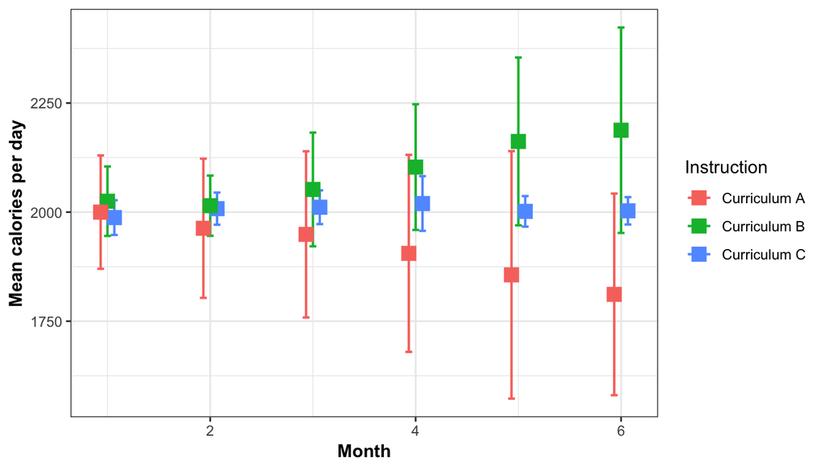

```r
library(ggplot2)

pd = position_dodge(.2) #jostles the position of points, so they are not on top of each other

ggplot(Data_summary, aes(x = Month,
                         y = mean_cal,
                         color = Instruction)) +
  geom_errorbar(aes(ymin=lower.ci,
                    ymax=upper.ci),
                width=.2, size=0.7, position=pd) +
  geom_point(shape=15, size=4, position=pd) +
  theme_bw() +
  theme(axis.title = element_text(face = "bold")) +
  ylab("Mean calories per day")
```

We’ll use the lme (linear mixed-effect models) function in the nlme library,

```r
library(nlme)
model = lme(Calories.per.day ~ Instruction + Month + Instruction*Month,
            random = ~1|Student, correlation = corAR1(form = ~Month | Student,
                                                      value = 0.4287),
                                                      data = Data,
                                                      method = "REML")
Anova(model)
```

```
## Analysis of Deviance Table (Type II tests)
##
## Response: Calories.per.day
##                     Chisq Df Pr(>Chisq)
## Instruction       10.4221  2   0.005456 **
## Month              0.0198  1   0.888045
## Instruction:Month 38.6045  2  4.141e-09 ***
## ---
## Signif. codes:  0 '***' 0.001 '**' 0.01 '*' 0.05 '.' 0.1 ' ' 1
```

The correlation component of the function describes autocorrelation structure. CorAR1 is used to indicate a temporal autocorrelation structure of order one, often abbreviated as AR(1), with form correlation = Structure(form = ~time | variable for experimental units). The value for the first order correlation can be specified : the 0.429 value was determined using the ACF function when determining autocorrelation of the residuals (will be shown below).

To test random effects in the model, we’ll use the `gls` function, with allows fitting of linear models using generalized least squares :

```r
model.fixed = gls(Calories.per.day ~ Instruction + Month + Instruction*Month,
                  data=Data,
                  method="REML")

anova(model,
      model.fixed)
```

```
##             Model df      AIC      BIC    logLik   Test L.Ratio p-value
## model           1  9 716.9693 736.6762 -349.4847
## model.fixed     2  7 813.6213 828.9489 -399.8106 1 vs 2 100.652  <.0001
```

Let’s check assumptions :

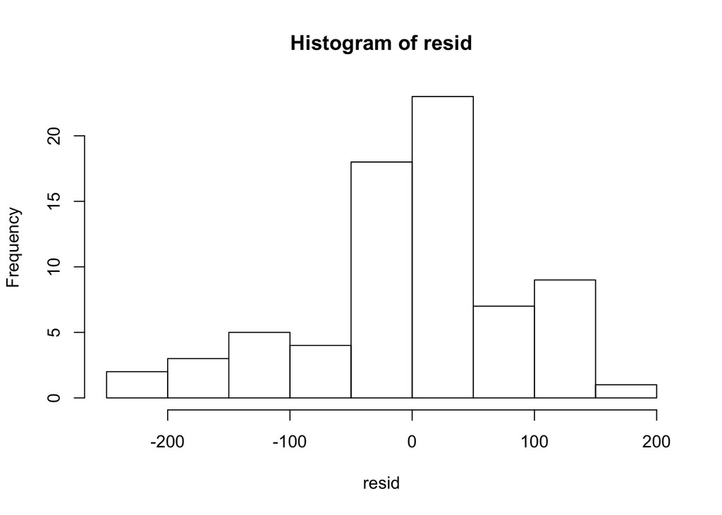

```r
resid = residuals(model)

hist(resid)
```

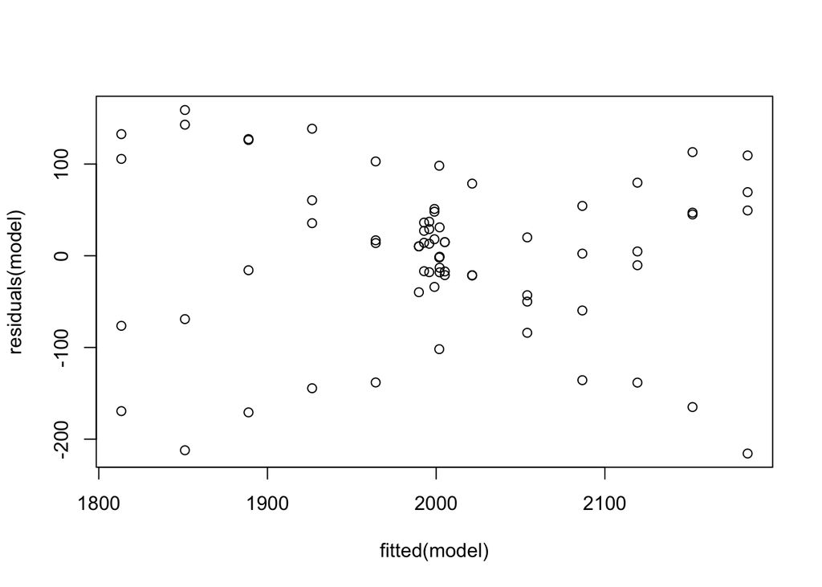

```r
plot(fitted(model),
     residuals(model))
```

Looking at autocorrelation, with ACF function:

```r
library(nlme)

model.a = gls(Calories.per.day ~ Instruction + Month + Instruction*Month,
             data=Data)

ACF(model.a,
    form = ~ Month | Student)
```

```
##   lag       ACF
## 1   0 1.0000000
## 2   1 0.8989822
## 3   2 0.7462712
## 4   3 0.6249217
## 5   4 0.5365430
## 6   5 0.4564673
```

```r
model.b = lme(Calories.per.day ~ Instruction + Month + Instruction*Month,
            random = ~1|Student,
            data=Data)

ACF(model.b)
```

```
##   lag        ACF
## 1   0  1.0000000
## 2   1  0.4286522
## 3   2 -0.1750233
## 4   3 -0.6283754
## 5   4 -0.8651088
## 6   5 -0.6957774
```

## Effect Sizes

- https://cran.r-project.org/web/packages/sjstats/vignettes/anova-statistics.html
- https://cran.r-project.org/web/packages/ARTool/vignettes/art-effect-size.html
- https://cran.r-project.org/web/packages/effsize/index.html

## Mann Whitney

```r
# independent 2-group Mann-Whitney U Test
wilcox.test(y~A)
# where y is numeric and A is A binary factor
```

## Power Analyses

Resources :  
* https://www.statmethods.net/stats/power.html  
* https://rcompanion.org/rcompanion/b_02.html

R package `pwr`

## Additional Resources

- An R Companion for the Handbook of Biological Statistics: https://rcompanion.org/rcompanion/a_02.html
- ANOVA Cookbook for R : http://www.cookbook-r.com/Statistical_analysis/ANOVA/#mixed-design-anova